# Your Digest for Thursday, Aug 10, 2023 11:59 PM

[output not shown]

### Gilbert syndrome

Patients develop episodes of jaundice when they undergo some type of stress (exercise, illness, dehydration, stress) etc.

First episodes occur around the onset of puberty.  
They other otherwise completely asymptomatic.  
The only biochemical abnormality is mild unconjugated hyper bilirubinaemia.

Underlying pathophysiology is *reduced* function of UGT enzyme.  
*Complete loss of function* of UGT causes Criggler Najjar syndrome.

Defects in hepatic excretion of the conjugated bilirubin occurs in Dublin Johnson and Rotor syndromes.

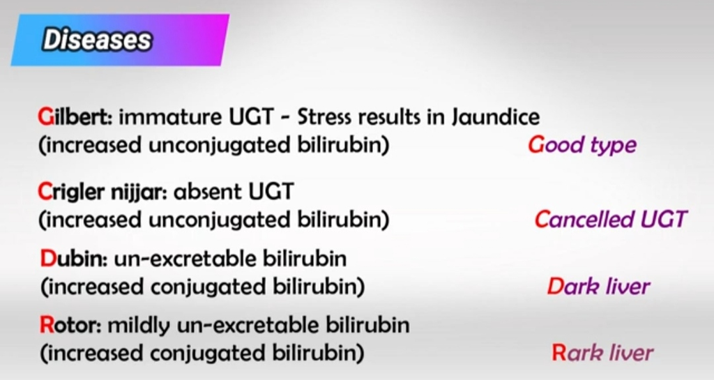

# Electrolytes and membrane potentials

## Mechanism of esablishment of membrane potentials.

When two compartments (i.e intra and extracellular) are separated by a selectively permeable membrane, charged ions will flow across the membrane according to their **concentration** and **electrostatic gradients**.

The electrostatic gradient and concentration gradient pull in opposite directions.  
The potential difference that exactly counteracts the chemical gradient is called the equilibrium potential.

The overall membrane potential is closest to the equilibrium potential of the ion with the most permeability. For cell membranes, this is **pottasium**.

According to these principles, it can be seen that the cell can change its membrane potentials by altering the permeability of the membrane to each of the ions.  
This provides a mechanism of cells to change their membrane potential.

Since the actual memrane potential of the cell is not equal to the equilibrium potentials for Na and K, these ions are *not in equilibrium.* It therefore, takes energy in the form of ATP to maintain the resting membrane potential by constantly pumping 3 sodium out and 2 pottasium in by the Na/K ATPase.

Na concentration inside the cell is around 5, Outside is around 150.  
K concentration inside the cells is abround 150, outside 5.

### Intro:

> The kidneys must
> 1. excrete acid in the amount equivalent to the production of non volatile acids in the body. (which varies with diet, disease etc)
> 2. and reabsorb filtered bicarbonate.  
>    **Both processes are linked to the nephrons ability to secrete H+ ions into the filtrate**.

#### Mechanisms of secretion of H+

- Proximal tubule - H+ is secreted in exchange for Na+ by the NHE3 (sodium hydrogen exchange) by secondary active trasnport.
- Distal tubule: H+ secretion is *independent of Na*. Secretion is driven by H+ ATPase pump. (primary active transport)
  - In acidosis, more H+ ATPases are inserted into the apical membrane -> more H+ pumped out.
  - **Aldoesterone** increases action of this pump.
  - In the DCT, there is also a H+/K+ pump (K in H out)

Highly lipid soluble local anaesthetics

1. are easily bound to tissue -> longer duration of action at the site.
2. They also happen to be highly protein bound -> longer clearance time.  
   Early symptoms are
3. circumoral numbness,
4. tongue paresthesia, and dizziness.
5. Sensory complaints may include tinnitus and blurred vision.
6. Excitatory signs, such as restlessness, agitation, nervousness, or paranoia, may progress to muscle twitches and seizures.

# ECG T waves

## Normal T wave

- Positive in most leads; Should be concordant with the QRS.
- Tallest in V2-V3.
- Asymmetric : descending limb is steeper than the ascending limb.
- Amplitude diminishes with age.

## T wave variations

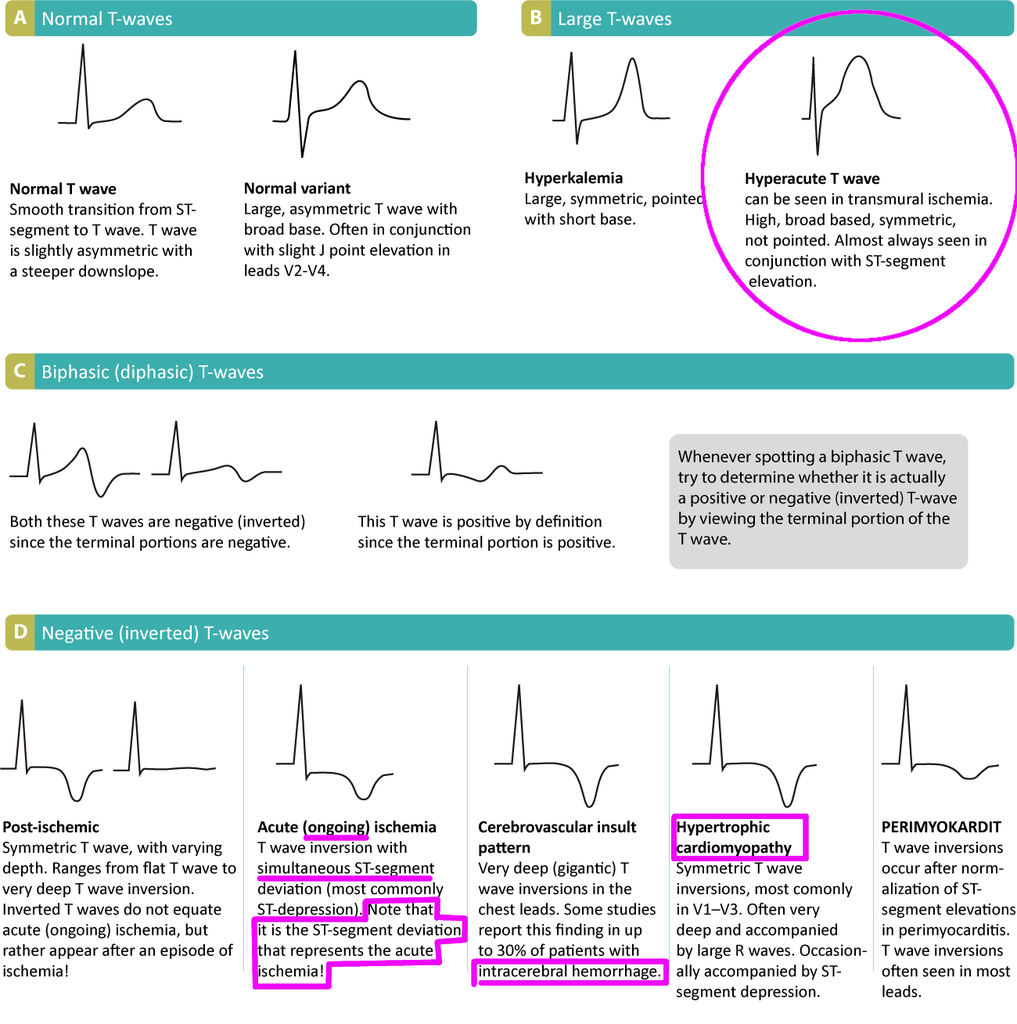

[Source](https://ecgwaves.com/the-t-wave-physiology-variants-and-ecg-features/)

### Normal T wave inversions

Isolated T inversion in V1 (common, concordant with QRS) OR V2 OR III or aVL is normal.  
T inversion in two contiguous leads it pathological.

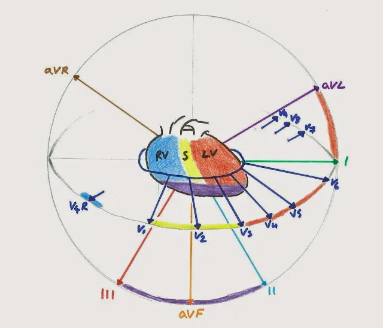

### T waves following and MI

1. T wave inversion is a late development in ischemia. ?Probably occurs after the acute event.
2. Regarding persistence of T wave inversion
   1. ECG made easy: T wave inversions are usually permanent.
   2. [[ECGchangesinMIEmergencyMedJournal.pdf|Source]] - T wave may or may not normalize; patients with normalization may have higher ejection fractions than those who do not.
3. Post ischemic T wave inversion are symmetric.

### Secondary causes of T wave inversion

- Bundle branch block,
- [pre-excitation](https://ecgwaves.com/topic/pre-excitation-avrt-wolff-parkinson-white-wpw-syndrome/),
- hypertrophy and
- ventricular pacemaker stimulation.

# ECG changes in hyperkalemia :

| Level | Changes | Basis |
| --- | --- | --- |
| 5.5 - 6.5 | Tall t waves | **Repolarization abnormalities** |
| 6.5 - 7 | P wave widening and flattening, broadening of PR interval | **Progressive atrial paralysis** |
| 7.0 - 9.0 | Sinus brady, AV block, AF, conduction blocks | Conduction abnormalities |
| > 9.0 | Sine wave | Peri arrest |

```
- screening for aneurysm is not done routinely. (Recommended in some situations such as when patient has a high risk job); CT angiography is used for screening;
- ? These patients can have "warning headaches" prior to rupture of an aneurysm.
```

# Rheumatoid arthiritis

[output not shown]

## Pathogenesis

> The pathogenesis of RA involves a complex interplay between B cells, T cells, and dendritic cells. A multitude of environmental and genetic factors *leads to loss of tolerance to the proteins that have a citrulline residue*, which leads to the production of autoantibodies like anti-cyclic citrullinated protein/peptide antibody (ACPA) and RF. - [Source](https://www.ncbi.nlm.nih.gov/books/NBK532898/)

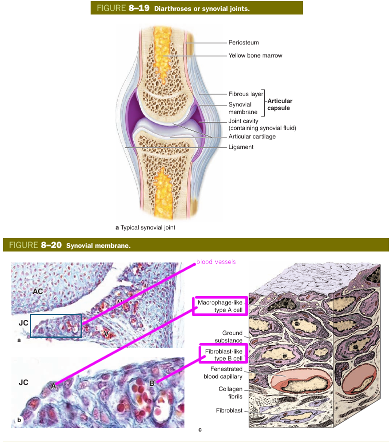

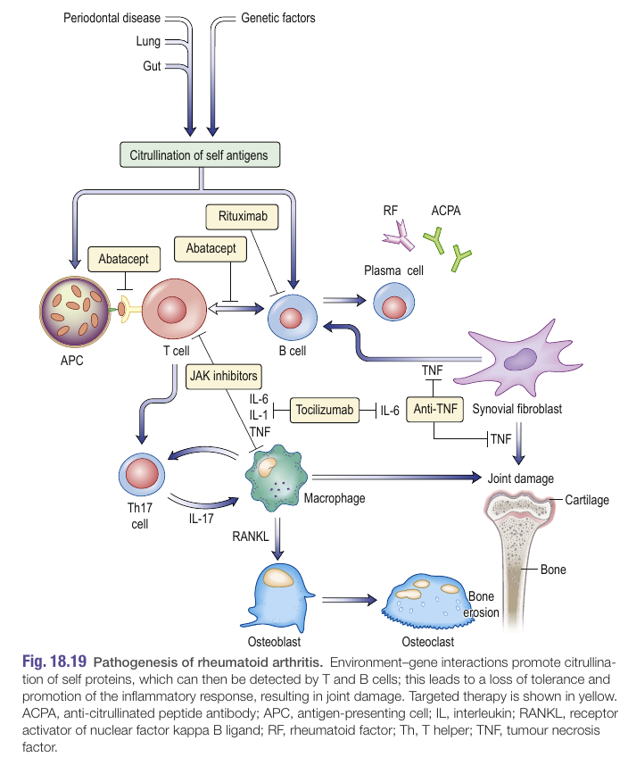

Chronic **symmetrical** polyarthritis + systemic inflammation.

*Primarily a synovial disease* -> Widespread persistent synovitis.  
Synovium proliferates, grows onto articular suface of cartilage and becomes invaded by inflammatory cells. Cartilage becomes thinned due to inhibited nutrient diffusion and action of synovial cytokines.

Interaction of macrophages + T + B cells -> Over production of TNF-alpha -> recruitment of inflammatory cells + stimulation of osteoclasts -> synovitis and joint destruction.

## Risk factors

Genetic associations

- certain HLA haplotypes
- development of antibodies against cistrullinated antibodies - (**ACPA**)

Environmental

- smoking

Autoantibodies

- Rheumatoid factors (autoantibodies to Fc portion of IgG) are found in 80% of RA patients.
- *ACPA is more senstive and specific*

## Rheumatoid factor

- They are IgM class antibodies directed against the Fc portion of IgG.
- Only moderately senstive and specific for RA.
- They can be present in normal individuals, non RA rheumatic diseases and non rheumatic diseases.
  - +ve in 4% of healthy people
  - chronic infection: Hep C, especially when Hep C leads to **Cryoglobulinaemia**, Tuberculosis, Subacute Infective endocarditis
  - Sjogren syndrome, MCTD, SLE
- Patients which higher RF titres have
  - More aggressive disease
  - More extra articular manifestations (like nodules and vasculitis)
  - Earlier development of RF -> more sever disease

## Presentation

**30 - 50 years** old.  
Progressive, *symmetrical*, peripheral polyarthritis, progressing over weeks or months.

As seen from EULAR diagnostic criteria, small joint involvement is more suggestive of RA than large joing involvement; but large join monoarthritis is not uncommmon. (knee or shoulder)

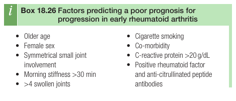

*Seronegative RA* - affects wrists more than fingers and has less symmetrical involvement.

### Different forms of RA

- Palindromic - acute onset within 24-48 hours, rare;
- Transient: lasts < 12 month; no permanent deformity.
- Remitting: active for several years then remits; no permanent damage.
- **chronic persistent**: *Commonest form; relapsing and remitting course, over years.*
- Rapidly progressive: Relentless progression over a few years leading to severe disability.

### Affected joints

PIP + MCP(DIP spared)  
MTP - common early manifestation  
Shoulders  
Elbows

# Cushing's syndrome

## Features of Cushing's syndrome

1. Osteoporosis
2. Hypertension
3. Facial plethora, proximal myopathy, striae, easy bruising

Commonest cause is iatrogenic;  
All glucocorticoids suppress ACTH -> ACTH, **and** serum cortisol will be low in iatrogenic cushing's syndrome.

> The diagnosis of Cushing syndrome is established when *at least two different* first-line tests are unequivocally abnormal, and physiologic hypercortisolism has been excluded

If a patients has feature of Chushing's syndrome

1. It has to be proved that the patient has elevated cortisol
2. The cause of elevated cortisol must be determined.

Initial testing to look for elevated cortisol:

1. bedtime salivary cortisol
   1. Measurement of salivary cortisol in the late evening before bedtime is based upon the fact that the normal evening nadir in serum cortisol is preserved in patients with physiologic hypercortisolism but not in those with Cushing syndrome
2. 24 hour urinary free cortisol - provides an overview of daily cortisol production because cortisol production is cyclical throughout the day.
3. Low dose DST
   1. The low-dose DSTs are standard **screening** tests to differentiate patients with *Cushing syndrome of any cause* from patients who do not have Cushing syndrome.
   2. The high-dose DSTs are **not** used to make the diagnosis of Cushing syndrome.
   3. They are used after the diagnosis of Cushing syndrome is made to distinguish patients with Cushing disease (Cushing syndrome caused by pituitary hypersecretion of ACTH) from patients with ectopic ACTH syndrome (Cushing syndrome caused by nonpituitary ACTH-secreting tumors)
   4. There are two forms of low dose DST
      1. Overnight 1mg dexamethasone suppresion test
      2. two day 2 mg DST
      3. Both will show impaired suppression of cortisol if the patient has Cushing's syndrome
4. For bedtime salivary cortisol and UFC, two abnormal tests are required.

If cortisol is elevated, **physiologic hypercortisolism** has to be excluded.  
AKA - **pseudo Cushing syndrome**.  
These patients usually do not have skin or muscle manifestations of Cushing Syndrome.  
Causes of pseudo-cushing syndrome (i.e causes of elevated cortisol)

1. #Pregnancy
2. Severe obesity / PCOS
3. Severe major depression
4. Poorly controlled DM
5. OSA

Because of various nuances, the above tests must be unequivocally elevated in order to diagnose Cushing's syndrome. Mild elevations are unlikely to indicate Cushign's syndrome.

## Determining the cause of hypercortisolism

### ACTH levels

Because of cyclical variations, testing at two different times is recommened.

ACTH < 5pg/ML = ACTH independent hypercortisolism

ACTH > 20pg/mL = ACTH dependent hypercortisolism.

ACTH dependent Hypercortisolism

1. The vast majority have **pituitary cortitroph adenoma** -(CUSHING'S DISEASE)
2. Other causes are ectopic ACTH and ectopic CRH.

### Dexamethasone suppression test

[figure not shown]